# Introducción al Análisis de Datos en Odontología

Sergio Uribe

# Introducción al análisis de datos para Odontología

**Estadística**: diseño, recolección, análisis, interpretación, presentación y organización de datos

Datos > Información > Conocimiento (colocar legos)

Flujo de trabajo: recolectar > limpiar > analizar > reportar

## Términos claves

Datos Variables Variables independientes y dependientes Población y muestra Parámetro y estadística Medidas de tendencia central: moda, mediana, promedio Medidas de disperción: desviación estándar, rango, recorrido intercuartil Distribución (normal, binomial, Poisson) Hipótesis Hipótesis nula Inferencia estadística Intervalo de confianza Error estándar de la media Significancia estadística y clínica

```r
library("tidyverse")
library("stringr")
library("broom")
```

# Descripción de datos

```r
df <- read_csv("2017_odon249.csv")
```

```r
glimpse(df)
```

```
Observations: 49
Variables: 13
$ Nombre       (chr) "AGUILEF GATICA,JAVIER FELIPE", "AGURTO CID,WALTER ALIRO",...
$ Sexo         (chr) "h", "h", "m", "m", "m", "m", "h", "h", "h", "m", "m", "h"...
$ 3 abril 2017 (dbl) 3.4, 3.4, 2.8, 5.2, 4.8, 5.7, 6.6, 4.8, 4.8, 6.6, 6.1, 3.6...
$ 10 abr       (dbl) 4.3, 4.9, 7.0, 5.9, 3.1, 5.9, 7.0, 5.4, 3.5, 3.9, 5.4, 3.1...
$ 17 abr       (dbl) 3.5, 1.0, 6.1, 4.2, 3.5, 5.1, 5.1, 3.5, 3.2, 4.2, 3.5, 5.1...
$ 24 abr       (dbl) 2.4, 5.4, 3.1, 4.9, 2.4, 2.4, 7.0, 1.0, 1.0, 4.3, 5.9, 3.1...
$ 8 mayo       (dbl) 4.2, 5.1, 4.2, 5.1, 5.1, 6.1, 7.0, 5.1, 2.9, 6.1, 6.1, 4.2...
$ 22 mayo      (dbl) 7.0, 7.0, 7.0, 5.1, 5.1, 5.1, 3.5, 1.0, 1.0, 7.0, 5.1, 5.1...
$ 29 mayo      (dbl) 3.1, 3.1, 5.9, 3.1, 3.9, 3.9, 2.4, 3.9, NA, 3.9, 3.1, 3.9,...
$ 5 junio      (dbl) 1.0, 1.0, 5.5, 3.0, 4.0, 3.0, 4.0, 2.0, 3.0, 4.0, 5.5, 5.5...
$ Logs         (int) 156, 132, 168, 339, 266, 342, 400, 82, 245, 247, 272, 180,...
$ 1a_acum      (dbl) 3.5, 4.6, 5.0, 5.7, 4.7, 4.6, 5.6, 5.1, 3.5, 5.8, 4.5, 4.5...
$ 1er_sem      (dbl) 4.6, 4.1, 4.6, 5.6, 5.5, 4.7, 5.3, 1.8, 3.7, 5.9, 5.9, 4.7...
```

```r
summary(df)
```

```
    Nombre              Sexo            3 abril 2017      10 abr         17 abr
 Length:49          Length:49          Min.   :2.20   Min.   :1.70   Min.   :1.00
 Class :character   Class :character   1st Qu.:3.33   1st Qu.:3.90   1st Qu.:3.50
 Mode  :character   Mode  :character   Median :4.80   Median :4.90   Median :4.20
                                       Mean   :4.52   Mean   :4.79   Mean   :4.34
                                       3rd Qu.:5.80   3rd Qu.:5.90   3rd Qu.:5.60
                                       Max.   :7.00   Max.   :7.00   Max.   :7.00
                                       NA's   :1
     24 abr         8 mayo        22 mayo        29 mayo       5 junio
 Min.   :1.00   Min.   :1.00   Min.   :1.00   Min.   :1.0   Min.   :1.00
 1st Qu.:1.70   1st Qu.:3.50   1st Qu.:2.30   1st Qu.:2.4   1st Qu.:2.00
 Median :3.10   Median :5.10   Median :3.50   Median :3.1   Median :3.00
 Mean   :3.19   Mean   :4.46   Mean   :4.04   Mean   :3.3   Mean   :3.26
 3rd Qu.:4.30   3rd Qu.:5.10   3rd Qu.:5.10   3rd Qu.:3.9   3rd Qu.:4.00
 Max.   :7.00   Max.   :7.00   Max.   :7.00   Max.   :7.0   Max.   :7.00
                                              NA's   :6
      Logs        1a_acum        1er_sem
 Min.   : 54   Min.   :3.10   Min.   :1.00
 1st Qu.:174   1st Qu.:4.30   1st Qu.:3.80
 Median :229   Median :4.70   Median :4.60
 Mean   :224   Mean   :4.79   Mean   :4.21
 3rd Qu.:272   3rd Qu.:5.30   3rd Qu.:5.00
 Max.   :400   Max.   :6.30   Max.   :5.90
               NA's   :4
```

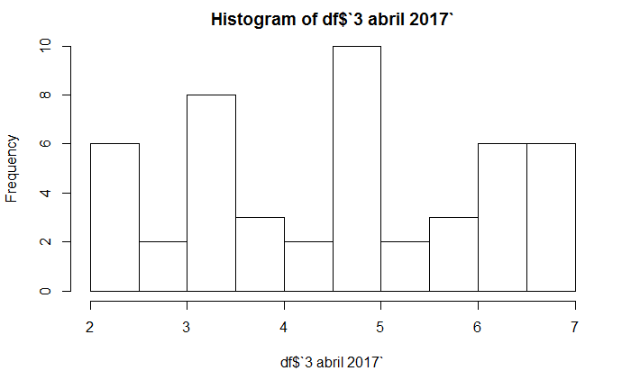

```r
hist(df$`3 abril 2017`)
```

```
Calling 'structure(NULL, *)' is deprecated, as NULL cannot have attributes.
  Consider 'structure(list(), *)' instead.
```

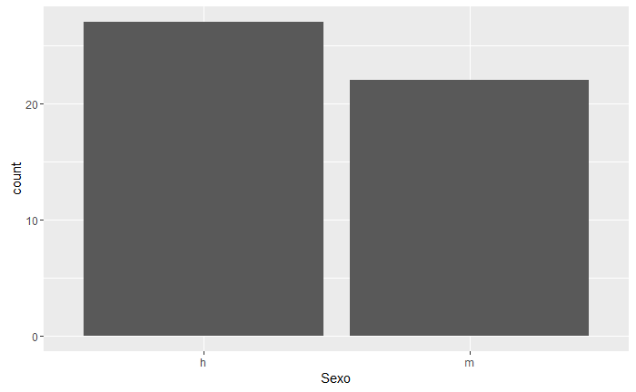

```r
df %>%
        ggplot(aes(x = Sexo)) +
        geom_bar()
```

```
Calling 'structure(NULL, *)' is deprecated, as NULL cannot have attributes.
  Consider 'structure(list(), *)' instead.
```

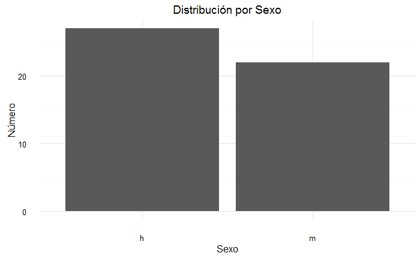

```r
df %>%
        ggplot(aes(x = Sexo )) +
        geom_bar() +
        labs(title = "Distribución por Sexo", y = "Número") +
        theme_minimal()
```

```r
df$Sexo <- str_replace(df$Sexo, "HoMujerbre", "Hombre")
df$Sexo <- str_replace(df$Sexo, "m", "Mujer")
```

¿Cómo lo hago para hacer un gráfico por prueba?

```r
head(df)
```

| Nombre | Sexo | 3 abril 2017 | 10 abr | 17 abr | 24 abr | 8 mayo | 22 mayo | 29 mayo | 5 junio | Logs | 1a_acum | 1er_sem |
| --- | --- | --- | --- | --- | --- | --- | --- | --- | --- | --- | --- | --- |
| AGUILEF GATICA,JAVIER FELIPE | h | 3.4 | 4.3 | 3.5 | 2.4 | 4.2 | 7.0 | 3.1 | 1.0 | 156 | 3.5 | 4.6 |
| AGURTO CID,WALTER ALIRO | h | 3.4 | 4.9 | 1.0 | 5.4 | 5.1 | 7.0 | 3.1 | 1.0 | 132 | 4.6 | 4.1 |
| ALMONACID PAREDES,CAMILA LUZ ELIANA | Mujer | 2.8 | 7.0 | 6.1 | 3.1 | 4.2 | 7.0 | 5.9 | 5.5 | 168 | 5.0 | 4.6 |
| ALVARADO NEGRÓN,GABRIELA LYA | Mujer | 5.2 | 5.9 | 4.2 | 4.9 | 5.1 | 5.1 | 3.1 | 3.0 | 339 | 5.7 | 5.6 |
| ÁLVAREZ ISLA,CONSTANZA ANDREA | Mujer | 4.8 | 3.1 | 3.5 | 2.4 | 5.1 | 5.1 | 3.9 | 4.0 | 266 | 4.7 | 5.5 |
| ANGULO GUTIÉRREZ,CAROLINA ANDREA | Mujer | 5.7 | 5.9 | 5.1 | 2.4 | 6.1 | 5.1 | 3.9 | 3.0 | 342 | 4.6 | 4.7 |

```r
df %>%
        gather("Prueba", "Nota", -c(Sexo,`Nombre`) )
```

| Nombre | Sexo | Prueba | Nota |
| --- | --- | --- | --- |
| AGUILEF GATICA,JAVIER FELIPE | h | 3 abril 2017 | 3.4 |
| AGURTO CID,WALTER ALIRO | h | 3 abril 2017 | 3.4 |
| ALMONACID PAREDES,CAMILA LUZ ELIANA | Mujer | 3 abril 2017 | 2.8 |
| ALVARADO NEGRÓN,GABRIELA LYA | Mujer | 3 abril 2017 | 5.2 |
| ÁLVAREZ ISLA,CONSTANZA ANDREA | Mujer | 3 abril 2017 | 4.8 |
| ANGULO GUTIÉRREZ,CAROLINA ANDREA | Mujer | 3 abril 2017 | 5.7 |
| ANTIPICHÚN RIFFO,ANDY GONZALO | h | 3 abril 2017 | 6.6 |
| ARELLANO VIVALLOS,JAIME IGNACIO | h | 3 abril 2017 | 4.8 |
| AREZO VÁSQUEZ,ANDRÉS ALEJANDRO | h | 3 abril 2017 | 4.8 |
| ÁVILA RUIZ,FERNANDA BELÉN | Mujer | 3 abril 2017 | 6.6 |

[output cut: 529 more lines]

```
Calling 'structure(NULL, *)' is deprecated, as NULL cannot have attributes.
  Consider 'structure(list(), *)' instead.
```

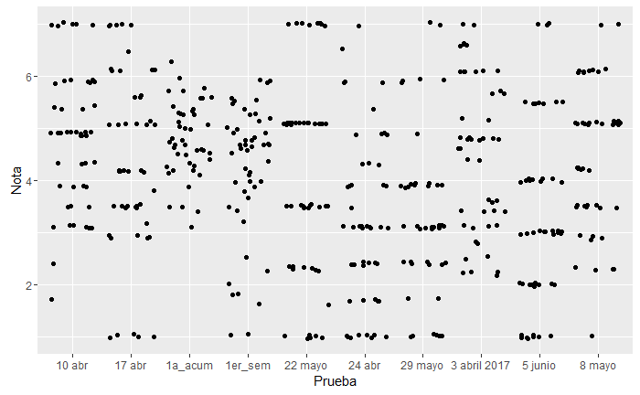

```r
df %>%
        select(-Logs) %>%
        gather("Prueba", "Nota", -c(Sexo,`Nombre` ) )%>%
        ggplot(aes(x = Prueba, y = Nota)) +
        geom_jitter()
```

```
Calling 'structure(NULL, *)' is deprecated, as NULL cannot have attributes.
  Consider 'structure(list(), *)' instead.
```

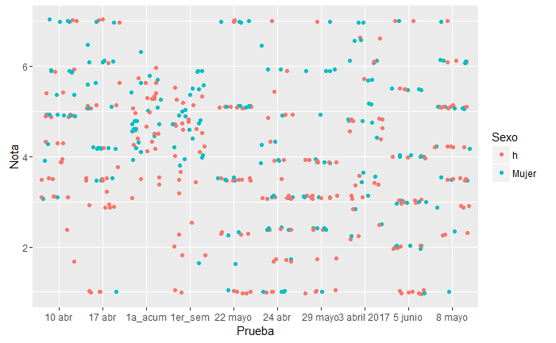

```r
df %>%
        select(-Logs) %>%
        gather("Prueba", "Nota", -c(Sexo,`Nombre` ) ) %>%
        ggplot(aes(x = Prueba, y = Nota, colour = Sexo)) +
        geom_jitter()
```

[output not shown]

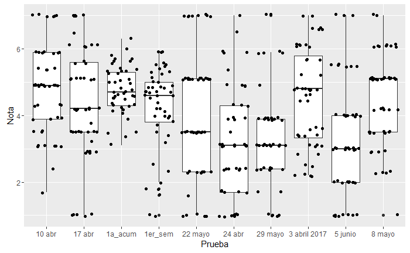

```r
df %>%
        select(-Logs) %>%
        gather("Prueba", "Nota", -c(Sexo,`Nombre` ) ) %>%
        ggplot(aes(x = Prueba, y = Nota)) +
        geom_boxplot() +
        geom_jitter()
```

Ahora vemos los datos en una tabla

```r
df <- df[complete.cases(df),] # dejo solo los que tienen datos completos
options(scipen=1, digits=3)
df %>%
                select(-Logs) %>%
        gather("Prueba", "Nota", -c(Sexo,`Nombre`, `1a_acum`, `1er_sem` ) ) %>%
        group_by(Prueba) %>%
        summarise(Promedio = mean(Nota), sd = sd(Nota))
```

| Prueba | Promedio | sd |
| --- | --- | --- |
| 10 abr | 4.94 | 1.19 |
| 17 abr | 4.52 | 1.55 |
| 22 mayo | 4.30 | 1.87 |
| 24 abr | 3.43 | 1.60 |
| 29 mayo | 3.44 | 1.57 |
| 3 abril 2017 | 4.73 | 1.38 |
| 5 junio | 3.38 | 1.62 |
| 8 mayo | 4.49 | 1.35 |

Correlación entre logs y seminarios

[output not shown]

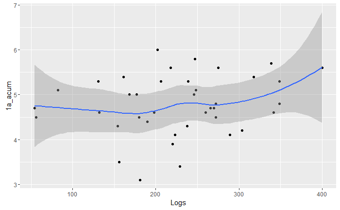

```r
df %>%
        ggplot(aes(x = Logs, y = `1a_acum`)) +
        geom_point() +
        geom_smooth()
```

[output not shown]

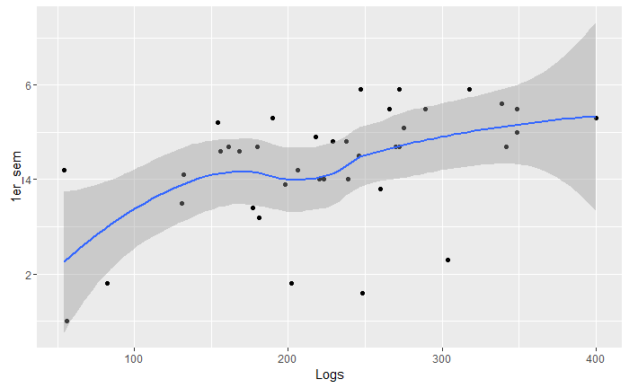

```r
df %>%
        ggplot(aes(x = Logs, y = `1er_sem`)) +
        geom_point() +
        geom_smooth()
```

```r
str(df)
```

```
Classes ‘tbl_df’, ‘tbl’ and 'data.frame':   39 obs. of  13 variables:
 $ Nombre      : chr  "AGUILEF GATICA,JAVIER FELIPE" "AGURTO CID,WALTER ALIRO" "ALMONACID PAREDES,CAMILA LUZ ELIANA" "ALVARADO NEGRÓN,GABRIELA LYA" ...
 $ Sexo        : chr  "h" "h" "Mujer" "Mujer" ...
 $ 3 abril 2017: num  3.4 3.4 2.8 5.2 4.8 5.7 6.6 4.8 6.6 6.1 ...
 $ 10 abr      : num  4.3 4.9 7 5.9 3.1 5.9 7 5.4 3.9 5.4 ...
 $ 17 abr      : num  3.5 1 6.1 4.2 3.5 5.1 5.1 3.5 4.2 3.5 ...
 $ 24 abr      : num  2.4 5.4 3.1 4.9 2.4 2.4 7 1 4.3 5.9 ...
 $ 8 mayo      : num  4.2 5.1 4.2 5.1 5.1 6.1 7 5.1 6.1 6.1 ...
 $ 22 mayo     : num  7 7 7 5.1 5.1 5.1 3.5 1 7 5.1 ...
 $ 29 mayo     : num  3.1 3.1 5.9 3.1 3.9 3.9 2.4 3.9 3.9 3.1 ...
 $ 5 junio     : num  1 1 5.5 3 4 3 4 2 4 5.5 ...
 $ Logs        : int  156 132 168 339 266 342 400 82 247 272 ...
 $ 1a_acum     : num  3.5 4.6 5 5.7 4.7 4.6 5.6 5.1 5.8 4.5 ...
 $ 1er_sem     : num  4.6 4.1 4.6 5.6 5.5 4.7 5.3 1.8 5.9 5.9 ...
```

[output not shown]

[output cut: 29 more lines]

[output not shown]

[output not shown]

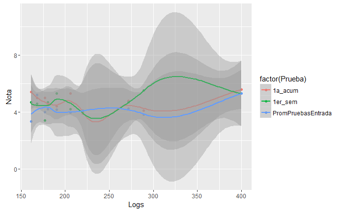

```r
df %>%
        gather("Prueba", "Nota", -c(Nombre, Sexo, Logs)) %>%
        filter(Prueba == c("PromPruebasEntrada", "1er_sem", "1a_acum", "Logs" ) ) %>%
        ggplot(aes(x = Logs, y = Nota, colour = factor(Prueba) )) +
        geom_point() +
        geom_smooth()
```

¿Hay diferencias en los promedios entre pruebas?

```r
df %>%
        gather("Prueba", "Nota", -c(Sexo,`Nombre` ) ) %>%
        do(anova(lm(Nota ~ Prueba, data = .)))
```

```
Analysis of Variance Table

Response: Nota
           Df  Sum Sq Mean Sq F value Pr(>F)
Prueba     10 1754683  175468     301 <2e-16 ***
Residuals 418  243474     582
---
Signif. codes:  0 ‘***’ 0.001 ‘**’ 0.01 ‘*’ 0.05 ‘.’ 0.1 ‘ ’ 1
```

```r
str(df2)
```

```
Classes ‘tbl_df’, ‘tbl’ and 'data.frame':   390 obs. of  4 variables:
 $ Nombre: chr  "AGUILEF GATICA,JAVIER FELIPE" "AGURTO CID,WALTER ALIRO" "ALMONACID PAREDES,CAMILA LUZ ELIANA" "ALVARADO NEGRÓN,GABRIELA LYA" ...
 $ Sexo  : chr  "Hombre" "Hombre" "Mujer" "Mujer" ...
 $ Prueba: chr  "3 abril 2017" "3 abril 2017" "3 abril 2017" "3 abril 2017" ...
 $ Nota  : num  3.4 3.4 2.8 5.2 4.8 5.7 6.6 4.8 6.6 6.1 ...
```

```r
summary(df2)
```

```
    Nombre              Sexo              Prueba               Nota
 Length:390         Length:390         Length:390         Min.   :1.00
 Class :character   Class :character   Class :character   1st Qu.:3.10
 Mode  :character   Mode  :character   Mode  :character   Median :4.30
                                                          Mean   :4.23
                                                          3rd Qu.:5.20
                                                          Max.   :7.00
```

Ok, ahora resulta que tengo varias notas 1

```r
table(df2$Prueba, df2$Nota)
```

```
                1 1.6 1.7 1.8  2 2.2 2.3 2.4 2.5 2.8 2.9  3 3.1 3.2 3.4 3.5 3.6 3.8
  10 abr        0   0   1   0  0   0   0   0   0   0   0  0   2   0   0   2   0   0
  17 abr        2   0   0   0  0   0   0   0   0   0   4  0   0   0   0   8   0   1
  1a_acum       0   0   0   0  0   0   0   0   0   0   0  0   1   0   1   1   0   0
  1er_sem       1   1   0   2  0   0   1   0   0   0   0  0   0   1   1   1   0   1
  22 mayo       3   0   0   0  0   0   7   0   0   0   0  0   0   0   0   9   0   0
  24 abr        3   0   5   0  0   0   0   7   0   0   0  0   8   0   0   0   0   0
  29 mayo       5   0   1   0  0   0   0   5   0   0   0  0  11   0   0   0   0   0
  3 abril 2017  0   0   0   0  0   2   0   0   1   1   0  0   3   0   3   0   3   0
  5 junio       5   0   0   0  7   0   0   0   0   0   0 10   0   0   0   0   0   0
  8 mayo        1   0   0   0  0   0   3   0   0   0   3  0   0   0   0   5   0   0

               3.9  4 4.1 4.2 4.3 4.4 4.5 4.6 4.7 4.8 4.9  5 5.1 5.2 5.3 5.4 5.5
  10 abr         4  0   0   0   4   0   0   0   0   0  12  0   0   0   0   4   0
  17 abr         0  0   0   7   0   0   0   0   0   0   0  0   6   0   0   0   0
```

[output cut: 20 more lines]

Elimino los 1

```
Calling 'structure(NULL, *)' is deprecated, as NULL cannot have attributes.
  Consider 'structure(list(), *)' instead.
```

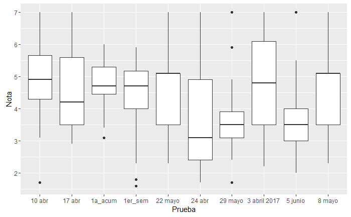

```r
df2 %>%
        ggplot(aes(x = Prueba, y = Nota)) +
        geom_boxplot()
```

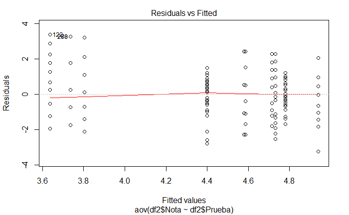

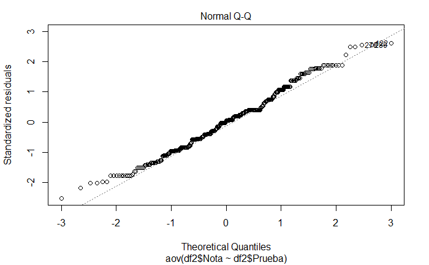

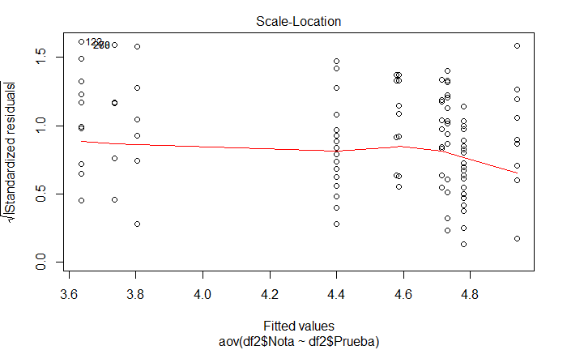

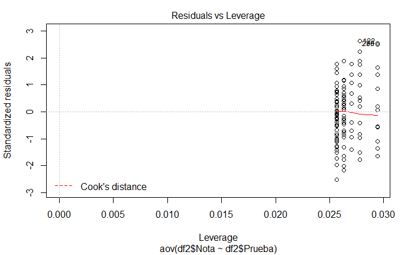

```r
summary(DiferenciaPorPrueba)
```

```
             Df Sum Sq Mean Sq F value Pr(>F)
df2$Prueba    9     75    8.38    4.93  3e-06 ***
Residuals   360    612    1.70
---
Signif. codes:  0 ‘***’ 0.001 ‘**’ 0.01 ‘*’ 0.05 ‘.’ 0.1 ‘ ’ 1
```

Ahora para ver cuál grupo tiene la diferencia,

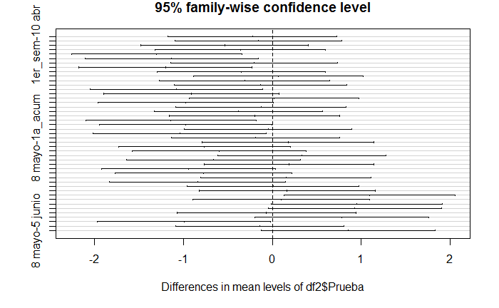

```r
head(df2)
```

```r
df2 %>%
        ggplot(aes(x = Sexo, y = Nota)) +
        geom_boxplot()
```

```r
df2 %>%
        group_by(Sexo) %>%
        summarise(Promedio = mean(Nota), sd = sd(Nota)) %>%
        ungroup()
```

```r
NotaxSexo <- aov(Nota ~ Sexo, data = df2)
```

```r
summary(NotaxSexo)
```

# ANOVA

Paquetes necesarios

```r
install.packages("tidyverse")
library("tidyverse")
```

```r
anova <- read_csv(url("http://bit.ly/ejemploAnova"))
```

examino los datos

```r
head(anova)
```

```r
glimpse(anova)
```

Veo un resumen de los datos, buscando especialmente NAs

```r
summary(anova)
```

Ahora que está todo ok, procedo a mirar los datos Con R base

```r
boxplot(HbA1cA~Grupo, data = anova)
```

Ahora con ggplot

```r
anova %>%
        ggplot(aes(x = Grupo, y = HbA1cA)) +
        geom_boxplot() +
        theme_minimal()
```

De todas maneras, para ver si existen outliers, agrego los datos individuales

```r
anova %>%
        ggplot(aes(x = Grupo, y = HbA1cA)) +
        geom_boxplot() +
        geom_jitter() +
        theme_minimal()
```

o mejor aun, grafico HbA1cA y HbA1cB al mismo tiempo para tener el cuadro global

```r
anova %>%
        gather("GrupoHb", "Valor", c(HbA1cA, HbA1cB)) %>%
        ggplot(aes(x = Grupo, y = Valor, colour = GrupoHb)) +
        geom_boxplot() +
        geom_jitter() +
        theme_minimal()
```

# Estadística inferencial

```r
install.packages("anonymizer")
library("anonymizer")
```

```r
df$`Nombre Estudiante 2` <- anonymize(df$`Nombre`, .n_chars = 5L)
?anonymize
```

```r
head(df)
```

```r
df %>%
        ggplot(aes(x = `10 abr`, y = `22 mayo`)) +
        geom_point() +
        geom_smooth(method=lm)
```

# Descriptiva

```r
df <- read_csv("Controles2017.csv")
```

Los veo

```r
glimpse(df)
```

```r
summary(df)
```

Considero solo los que no tienen NA

```r
df <- df[complete.cases(df),] #elimino NAs
```

verifico

```r
summary(df)
```

Creo una nueva variable que se llama PromPruebasChicas

```r
head(df)
df <- df %>%
        rowwise() %>%
        mutate(PromPruebasChicas = mean(`3 abril 2017`:`22 mayo`))
```

de wide a long

```r
df2 <- df %>%
        gather("Prueba", "Nota", -c(Sexo,`Nombre` ) )
# y elimino 1s
df2 <- df2 %>%
        filter(Nota > 1)
# reemplazo el df original por este que no contiene los 1

df <- df2 %>%
        spread(key = Prueba, value = Nota)
```

Veo las notas

```r
df2 %>%
        ggplot(aes( x = Prueba, y = Nota)) +
        geom_boxplot()
```

```r
df %>%
        ggplot(aes(x = `1_teo`)) +
        geom_histogram(binwidth = 0.5)
head(df)
df %>%
        ggplot(aes(x = PromPruebasChicas, y = `1_teo`)) +
        geom_point() +
        geom_smooth(method=lm)
```

```r
df2 %>%
        ggplot(aes(x = Prueba, y = Nota)) +
        geom_bar(stat = "summary", fun.y = "mean")
```

```r
df %>%
        ggplot(aes(x = Sexo)) +
        geom_bar()
```

```r
df3 <- df %>%
        select(-c(`1_teo`, `PromPruebasChicas`))
head(df3)
df3  %>%
        gather("Prueba", "Nota", -c(Sexo,`Nombre` ) ) %>%
        group_by(Prueba) %>%
        summarise(Promedio = mean(Nota, na.rm=TRUE)) %>%
        ggplot(aes(x = Prueba, y = Promedio, group=1)) +
        geom_point() +
        geom_line() +
        stat_smooth(method="loess", span=0.1, se=TRUE, alpha=0.3)
```

```r
table(df2$Prueba)
```

```r
head(df)
df3 %>%
        gather("Prueba", "Nota", -c(Sexo,`Nombre` ) ) %>%
        ggplot(aes(x = Prueba, y = Nota, colour = Sexo)) +
        geom_boxplot()
```

```r
library(anonymizer)
```